# TempConduction 열전도도

서강대학교 20121802 김재현

2023-10-14

### 데이터 준비

```r
getwd()
```

```
## [1] "/Users/jaahyun/Documents/R_visualizationApplications/2. TempConduction"
```

#setwd(‘./2. TempConduction’)

```r
TempConduction = read.csv('TempConduction.csv')
head(TempConduction)
```

```
##       Cu  Glass     Fe Cu.Carbon Glass.Carbon Fe.Carbon
## 1 22.860 22.962 22.854    22.563       22.315    22.590
## 2 22.590 23.037 22.870    22.439       22.283    22.536
## 3 22.510 22.779 22.774    22.337       22.142    22.661
## 4 22.412 22.655 22.736    22.423       21.979    22.892
## 5 22.423 22.795 22.617    22.396       22.001    22.983
## 6 22.353 22.687 22.607    22.369       21.974    23.005
```

column은 막대의 재료 row는 열화상 카메라(ir camera)에 감지된, 같은 y값을 갖는 1픽셀내 온도

```r
str(TempConduction)
```

```
## 'data.frame':    162 obs. of  6 variables:
##  $ Cu          : num  22.9 22.6 22.5 22.4 22.4 ...
##  $ Glass       : num  23 23 22.8 22.7 22.8 ...
##  $ Fe          : num  22.9 22.9 22.8 22.7 22.6 ...
##  $ Cu.Carbon   : num  22.6 22.4 22.3 22.4 22.4 ...
##  $ Glass.Carbon: num  22.3 22.3 22.1 22 22 ...
##  $ Fe.Carbon   : num  22.6 22.5 22.7 22.9 23 ...
```

```r
library(tidyverse)
```

### range값 구하기 for normalization

```r
CuDiff = diff(range(TempConduction$Cu))
GlassDiff = diff(range(TempConduction$Glass))
FeDiff = diff(range(TempConduction$Fe))
Cu.CarbonDiff = diff(range(TempConduction$Cu.Carbon))
Glass.CarbonDiff = diff(range(TempConduction$Glass.Carbon))
Fe.CarbonDiff = diff(range(TempConduction$Fe.Carbon))
```

### Normalized TempConduction

```r
TempConductionN = bind_cols(TempConduction$Cu/CuDiff,
                            TempConduction$Glass/GlassDiff,
                            TempConduction$Fe/FeDiff,
                            TempConduction$Cu.Carbon/Cu.CarbonDiff,
                            TempConduction$Glass.Carbon/Glass.CarbonDiff,
                            TempConduction$Fe.Carbon/Fe.CarbonDiff)
```

### column 변수에 이름 붙히기 + No 변수 추가

```r
TempConductionN %>% rename('CuN' = '...1','GlassN'= '...2','FeN'= '...3',
                           'Cu.CarbonN'= '...4','Glass.CarbonN'= '...5',
                           'Fe.CarbonN'= '...6') -> TempConductionN
TempConductionN$No = c(1:162)
```

###wide to long type(for tidy data)

```r
TempConductionN %>% pivot_longer(c(CuN:Fe.CarbonN),names_to = 'materials',
                                 values_to = 'temp')->TidyTempConN
head(TidyTempConN)
```

```
## # A tibble: 6 × 3
##      No materials      temp
##   <int> <chr>         <dbl>
## 1     1 CuN           0.485
## 2     1 GlassN        0.474
## 3     1 FeN           0.483
## 4     1 Cu.CarbonN    0.494
## 5     1 Glass.CarbonN 0.483
## 6     1 Fe.CarbonN    0.505
```

### Plotting

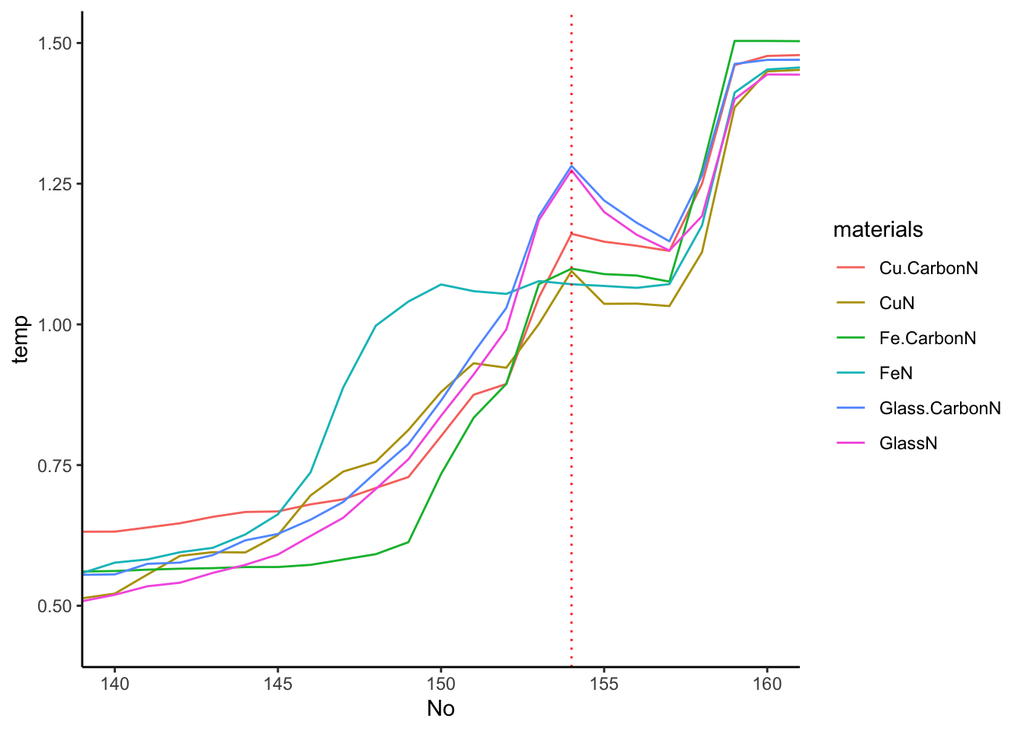

```r
ggplot(TidyTempConN) + geom_line(aes(x = No, y = temp, color = materials)) +
  coord_cartesian(xlim = c(140,160)) +
  geom_vline(xintercept = 154, linetype = 'dotted', color = 'red') +
  theme_classic()
```

plot을 그려보니, 160행부터 156, 157행까지 온도가 줄어들다가, 154행에서 온도가 정점을 찍는다. 해당 실험 열 화상 이미지를 확인해봤을 때, hotplate와 막대가 닿는 곳에서 온도가 다시 올라가는 것을 확인했다. 결과분석에서는 막대의 온도분포를 확인해야하기 때문에 **154행부터 1행까지의 결과만 활용하는 것이 합당하다고 판단했다.**

### TempConduction의 154 다음 행 부터 제거 및 다시 normalize + No를 길이로 변경

```r
TempConduction = TempConduction[-155:-162,]
```

### range값 구하기 for normalization

자료 길이 변경으로 다시 계산

```r
CuDiff = diff(range(TempConduction$Cu))
GlassDiff = diff(range(TempConduction$Glass))
FeDiff = diff(range(TempConduction$Fe))
Cu.CarbonDiff = diff(range(TempConduction$Cu.Carbon))
Glass.CarbonDiff = diff(range(TempConduction$Glass.Carbon))
Fe.CarbonDiff = diff(range(TempConduction$Fe.Carbon))
```

### Normalized TempConduction 2

```r
TempConductionN2 = bind_cols(TempConduction$Cu/CuDiff,
                             TempConduction$Glass/GlassDiff,
                             TempConduction$Fe/FeDiff,
                             TempConduction$Cu.Carbon/Cu.CarbonDiff,
                             TempConduction$Glass.Carbon/Glass.CarbonDiff,
                             TempConduction$Fe.Carbon/Fe.CarbonDiff)
TempConductionN2 %>% rename('CuN' = '...1','GlassN'= '...2','FeN'= '...3',
                           'Cu.CarbonN'= '...4','Glass.CarbonN'= '...5',
                           'Fe.CarbonN'= '...6') -> TempConductionN2
head(TempConductionN2)
```

```
## # A tibble: 6 × 6
##     CuN GlassN   FeN Cu.CarbonN Glass.CarbonN Fe.CarbonN
##   <dbl>  <dbl> <dbl>      <dbl>         <dbl>      <dbl>
## 1 0.761  0.571 0.779      0.724         0.595      0.848
## 2 0.752  0.573 0.779      0.720         0.594      0.846
## 3 0.749  0.567 0.776      0.717         0.590      0.851
## 4 0.746  0.563 0.775      0.720         0.586      0.860
## 5 0.746  0.567 0.771      0.719         0.586      0.863
## 6 0.744  0.564 0.770      0.718         0.586      0.864
```

### No를 길이(length)로 변경

No순서를 반대로 하여, length가 hotplate기준으로 막대 축방향 거리가 되도록 한다. 막대길이가 300mm라는 물성치가 주어진 상태

```r
TempConductionN2$length = rev(c(1:154))
TempConductionN2$length = (300/154)*TempConductionN2$length
head(TempConductionN2)
```

```
## # A tibble: 6 × 7
##     CuN GlassN   FeN Cu.CarbonN Glass.CarbonN Fe.CarbonN length
##   <dbl>  <dbl> <dbl>      <dbl>         <dbl>      <dbl>  <dbl>
## 1 0.761  0.571 0.779      0.724         0.595      0.848   300
## 2 0.752  0.573 0.779      0.720         0.594      0.846   298.
## 3 0.749  0.567 0.776      0.717         0.590      0.851   296.
## 4 0.746  0.563 0.775      0.720         0.586      0.860   294.
## 5 0.746  0.567 0.771      0.719         0.586      0.863   292.
## 6 0.744  0.564 0.770      0.718         0.586      0.864   290.
```

### tidy한 데이터로 변환

```r
TempConductionN2 %>% pivot_longer(c(CuN:Fe.CarbonN),names_to = 'materials',
                                 values_to = 'temp')->TidyTempConN2
head(TidyTempConN2)
```

```
## # A tibble: 6 × 3
##   length materials      temp
##    <dbl> <chr>         <dbl>
## 1    300 CuN           0.761
## 2    300 GlassN        0.571
## 3    300 FeN           0.779
## 4    300 Cu.CarbonN    0.724
## 5    300 Glass.CarbonN 0.595
## 6    300 Fe.CarbonN    0.848
```

### plotting

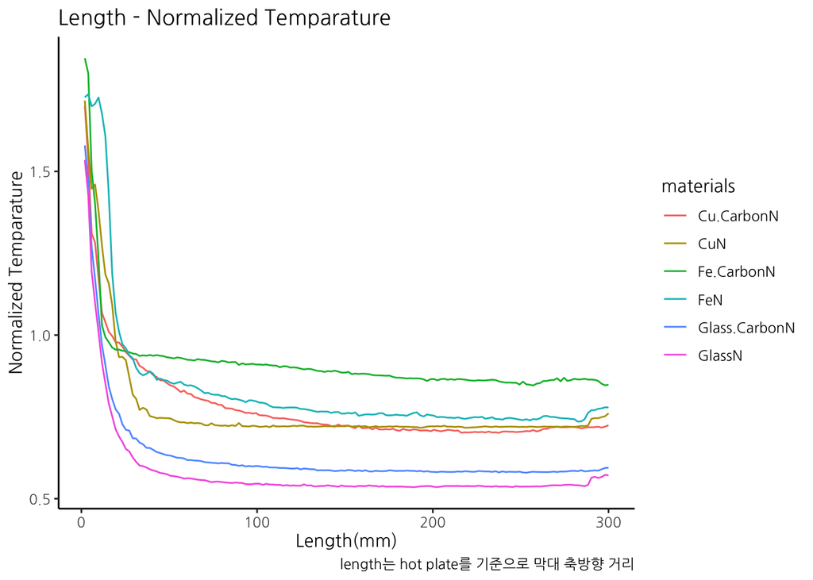

```r
ggplot(TidyTempConN2) + geom_line(aes(x = length, y = temp, color = materials)) +
  ylab('Normalized Temparature') +
  xlab('Length(mm)') +
  labs(title = 'Length - Normalized Temparature', caption = 'length는 hot plate를 기준으로 막대 축방향 거리' ) +
  #coord_cartesian(xlim = c(140,160)) +
  theme_classic(base_family = 'NanumGothic')
```

### Thermal Conductivity 계산

```r
#length를 meter 로 단위변환
TempConduction$Length = TempConductionN2$length*10^(-3)

# Temp 단위를 kelvin으로 변환(celcius +273.15)
TempConduction$CuK = TempConduction$Cu + 273.15
TempConduction$GlassK = TempConduction$Glass + 273.15
TempConduction$FeK = TempConduction$Fe + 273.15

TempConduction$Cu.CarbonK = TempConduction$Cu.Carbon + 273.15
TempConduction$Glass.CarbonK = TempConduction$Glass.Carbon + 273.15
TempConduction$Fe.CarbonK = TempConduction$Fe.Carbon + 273.15
```

### Cu 열전도도 계산

```r
#Cu
TempConduction$CuThermalC = 0.01257*25/
  (2*0.00001257*TempConduction$CuK)*
  (TempConduction$CuK - 293.35) *
  (TempConduction$Length)^2
mean(TempConduction$CuThermalC)
```

```
## [1] 1.993109
```

```r
#방사율 보정
1.993109 * 1/0.04
```

```
## [1] 49.82773
```

실제 Cu 의 열전도도는 385

### Glass 열전도도 계산

```r
TempConduction$GlassThermalC = 0.01257*25/
  (2*0.00001257*TempConduction$GlassK)*
  (TempConduction$GlassK - 293.35) *
  (TempConduction$Length)^2
mean(TempConduction$GlassThermalC)
```

```
## [1] 2.080402
```

```r
# 방사율 보정
2.080402 * 1/0.95
```

```
## [1] 2.189897
```

유리의 실제 열전도도는 1

### Fe 열전도도 계산

```r
TempConduction$FeThermalC = 0.01257*25/
  (2*0.00001257*TempConduction$FeK)*
  (TempConduction$FeK - 293.35) *
  (TempConduction$Length)^2
mean(TempConduction$FeThermalC)
```

```
## [1] 2.560583
```

```r
# 방사율 보정
2.560583 * 1/0.06
```

```
## [1] 42.67638
```

철 실제 열전도도 79.5

방사율 보정을 해도 오차가 많이 난다. -> 열적 평형 이뤄지지 않아서 충분히 열이 전파되지 않은 상황일수 있다.

### 각 재료에 Carbon spray 뿌린 막대 열전도도 계산

방사율 보정은 하지 않았음.

### Cu.Carbon 열전도도

```r
TempConduction$Cu.CarbonThermalC = 0.01257*25/
  (2*0.00001257*TempConduction$Cu.CarbonK)*
  (TempConduction$Cu.CarbonK - 293.35) *
  (TempConduction$Length)^2

mean(TempConduction$Cu.CarbonThermalC)
```

```
## [1] 2.731238
```

### Glass.Carbon 열전도도

```r
TempConduction$Glass.CarbonThermalC = 0.01257*25/
  (2*0.00001257*TempConduction$Glass.CarbonK)*
  (TempConduction$Glass.CarbonK - 293.35) *
  (TempConduction$Length)^2

mean(TempConduction$Glass.CarbonThermalC)
```

```
## [1] 2.278669
```

### Fe.Carbon 열전도도

```r
TempConduction$Fe.CarbonThermalC = 0.01257*25/
  (2*0.00001257*TempConduction$Fe.CarbonK)*
  (TempConduction$Fe.CarbonK - 293.35) *
  (TempConduction$Length)^2

mean(TempConduction$Fe.CarbonThermalC)
```

```
## [1] 3.69476
```

### 일부 데이터 추출 : length, 구리, 유리, 철

```r
TempC = tibble(Length = rev(TempConduction$Length), Cu = rev(TempConduction$Cu),
       Glass = rev(TempConduction$Glass), Fe = rev(TempConduction$Fe) )
head(TempC)
```

```
## # A tibble: 6 × 4
##    Length    Cu Glass    Fe
##     <dbl> <dbl> <dbl> <dbl>
## 1 0.00195  51.6  61.7  50.7
## 2 0.00390  47.1  57.4  50.9
## 3 0.00584  43.5  48.0  49.9
## 4 0.00779  43.9  44.1  50.1
## 5 0.00974  41.5  40.6  50.6
## 6 0.0117   38.3  36.8  49.2
```

```r
TempC %>% pivot_longer(c(Cu:Fe), names_to = 'materials',values_to = 'temp') ->
  TempCtidy
head(TempCtidy)
```

```
## # A tibble: 6 × 3
##    Length materials  temp
##     <dbl> <chr>     <dbl>
## 1 0.00195 Cu         51.6
## 2 0.00195 Glass      61.7
## 3 0.00195 Fe         50.7
## 4 0.00390 Cu         47.1
## 5 0.00390 Glass      57.4
## 6 0.00390 Fe         50.9
```